# Meu perfil

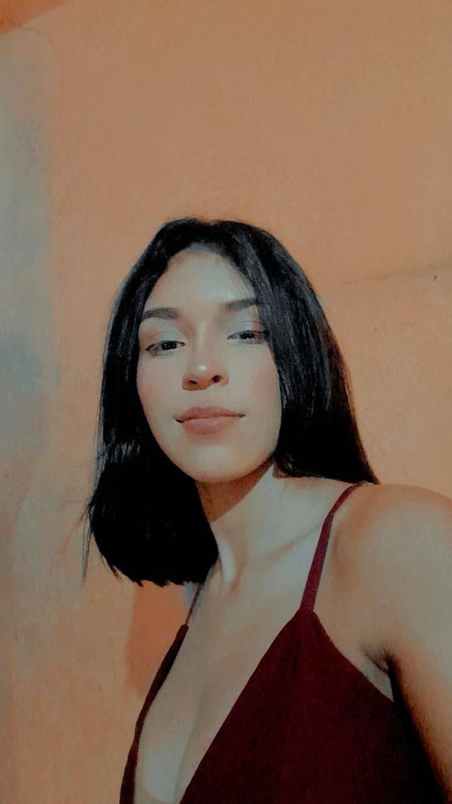

**Nome:** Claudiane Pereira  
**Idade:** 18  
**Sexo:** Femenino  
**Nascionalidade:** Brasileira  
**Endereço:** Tv: Manoel Cayres, 211, Pajuçara  
**Email:** Claudianes2005@gmail.com  
**Telefone:** (93) 991742045 **Escolaridade:** Ensino Superior **Curso** Engenharia de Aquicultura

Profissional comprometido, destaco-me pela comunicação eficaz, pensamento analítico e habilidade em trabalhar em equipe. Sou eficiente na gestão do tempo, garantindo resultados de alta qualidade. Além do ambiente profissional, minha paixão pela dança e leitura de livros de romance reflete meu compromisso com o crescimento holístico. Estou entusiasmado para contribuir ativamente em ambientes desafiadores e inovadores, alinhando minhas habilidades e paixões.

# Currículo Lattes

[Currículo Lattes](https://www.lattes.cnpq.br/)

# Rede social

minhas redes sociais.

[fecebook](https://www.facebook.com/?locale=pt_BR)

[figure not shown]

[Instagram](https://www.instagram.com/)

[figure not shown]

[figure not shown]

# Sobre

**Equipe**  
**Orietador:**Carlos Zarzar  
**Monitores:**Daniel Pinto, Gabriel Rodrigues e Luan Patrick  
**Discente:**Claudiane Pereira

**Objetivos** O curso tem o intuito de ensinar os discentes da universidade Federal do Oeste do Pará (Ufopa) *Campus* Monte Alegre a liguagem de programação. Eles irão aprender a utilizar os programas de versionamneto Git e GitHub, construir roteiros no RMarkdown, criar Dashboards Interativo e aplicativos no R Shiny. Esse projeto servirá para ajudar em disciplinas que envolveram a utilização do programa R, em trabalhos acadêmicos e no enriquecimento do conhecimento em programação muito exigido no mercado de trabalho.